Lake Name: Montgomery Lake

Lake acreage: 19.6

County: SULLIVAN

PWLID: 1401-0091

Waterbody Classification: B

Coordinates: 41.525387,-74.919204

Is this waterbody a public water supply: No

Are there DOH desingated beaches on this waterbody: No

Open Water Indicators

2018 Sampling Results

Seasonal Change

Longterm Avg

Season Avg

Season Diff From Avg

05-28

06-10

06-24

07-08

07-22

08-05

08-19

09-03

Clarity (m)

3.90

4.55

4.70

5.70

5.05

4.60

4.20

3.75

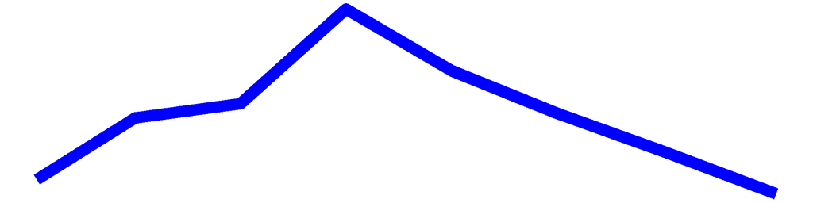

3.00921053

4.5562500

Surface TP (mg/L)

0.04

0.02

0.01

0.01

0.01

0.01

0.01

0.01

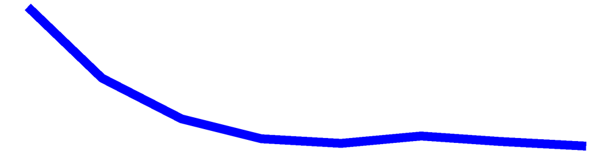

0.01438974

0.0124375

Surface TDP (mg/L)

0.00

0.01

0.00

0.00

0.00

0.00

0.00

0.00

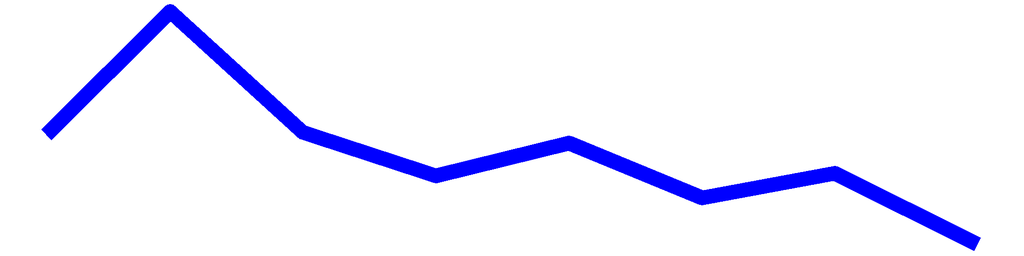

0.0038875

Deep TP (mg/L)

Deep TDP (mg/L)

TN (mg/L)

0.63

0.36

0.41

0.30

0.31

0.35

0.32

0.33

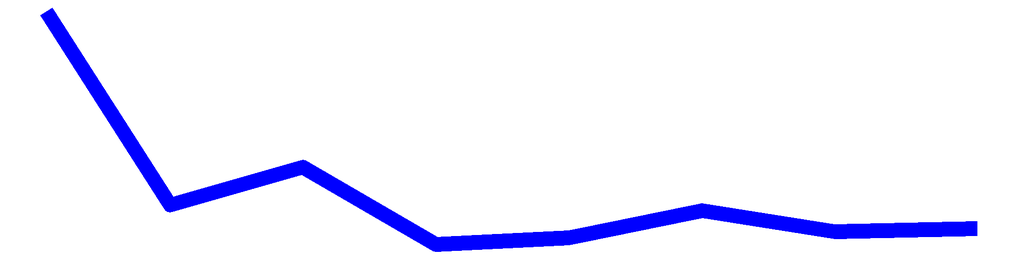

0.39203235

0.3795217

TDN (mg/L)

0.52

0.35

0.38

0.28

0.34

0.39

0.32

0.35

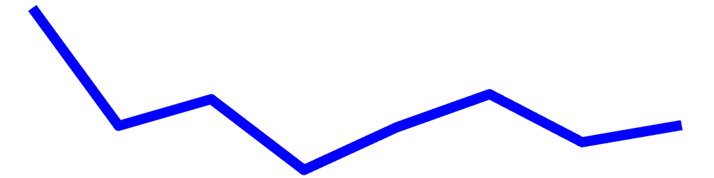

0.19800000

0.3668750

TN:TP

17.49

17.67

36.43

44.06

53.11

46.84

51.11

61.57

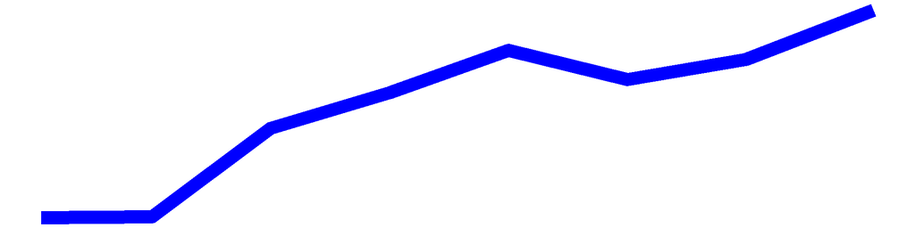

41.0353658

Surface NH3 (mg/L)

0.03

0.02

0.00

0.03

0.02

0.02

0.01

0.02

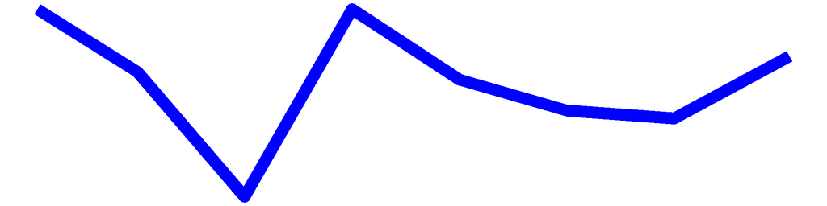

0.02184634

0.0197500

Deep NH3 (mg/L)

Chl.a (ug/L)

18.60

13.20

2.10

0.80

4.20

3.80

3.50

5.20

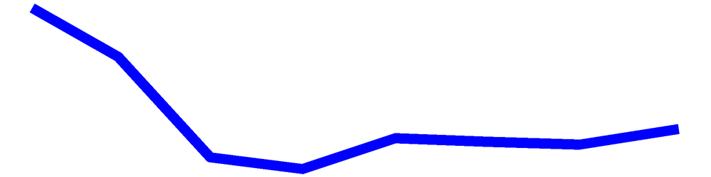

7.37912766

6.4250000

pH

7.33

7.00

6.67

6.70

6.75

7.32

6.71

6.97

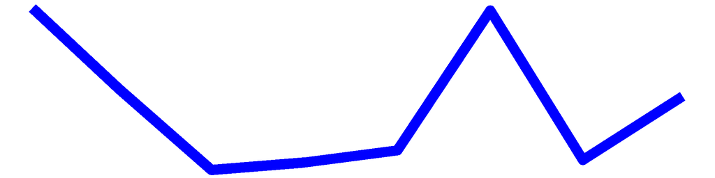

7.42404255

6.9312500

Cond (umho/cm)

176.70

116.10

101.40

203.10

208.30

196.00

196.50

196.80

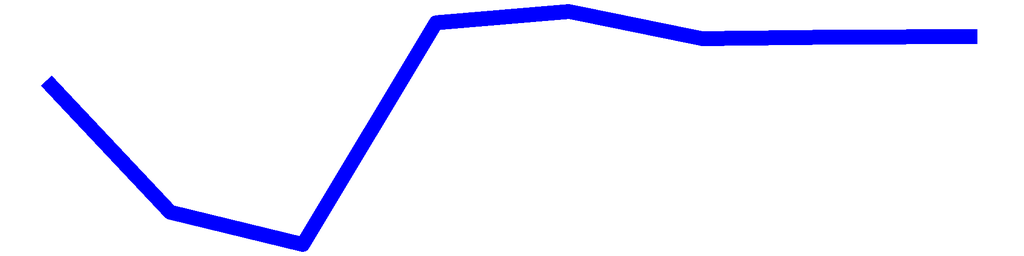

137.87872340

174.3625000

Surface Calcium (mg/L)

Bottom Calcium (mg/L)

Surface Chloride (mg/L)

43.20

40.40

37.57000000

41.8000000

Bottom Chloride (mg/L)

Upper Temp (degC)

22.00

22.00

26.00

27.00

27.00

28.00

26.00

28.00

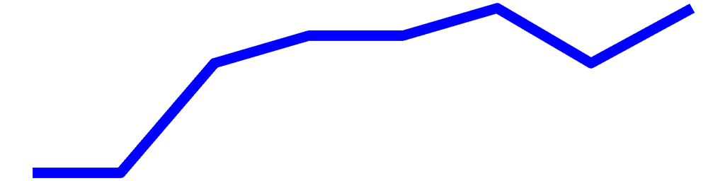

25.45833333

25.7500000

Deep Temp (degC)

FP BG Chl.a (ug/L)

19.76

6.29

5.65

0.97

2.61

2.96

4.47

6.65

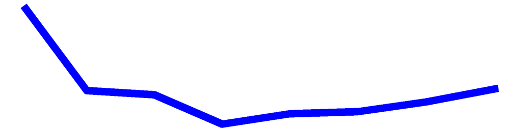

6.1713750

## Montgomery Lake – Sampling Season Results

### HABs Status

#### Open Water Algae

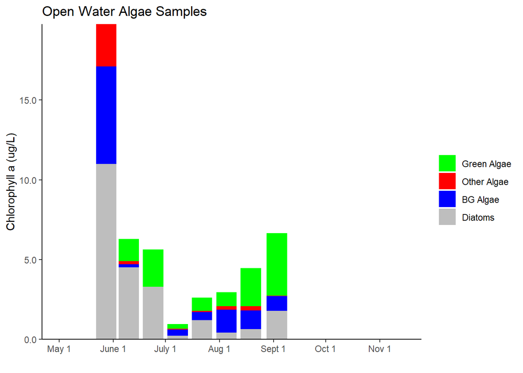

#### Shoreline Algae

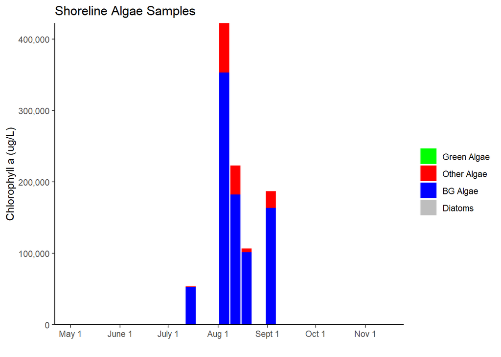

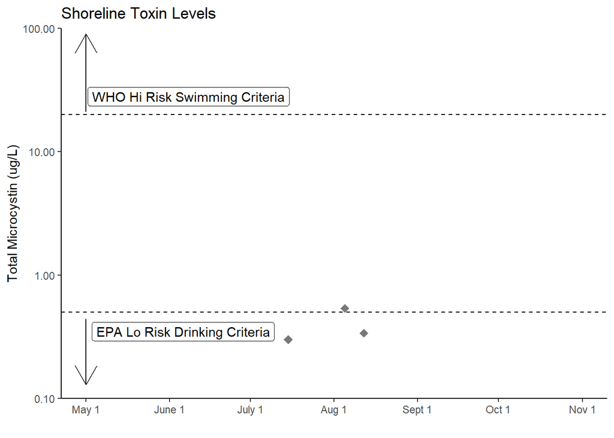

## Montgomery Lake Long-Term Trend Analysis

#### Clarity

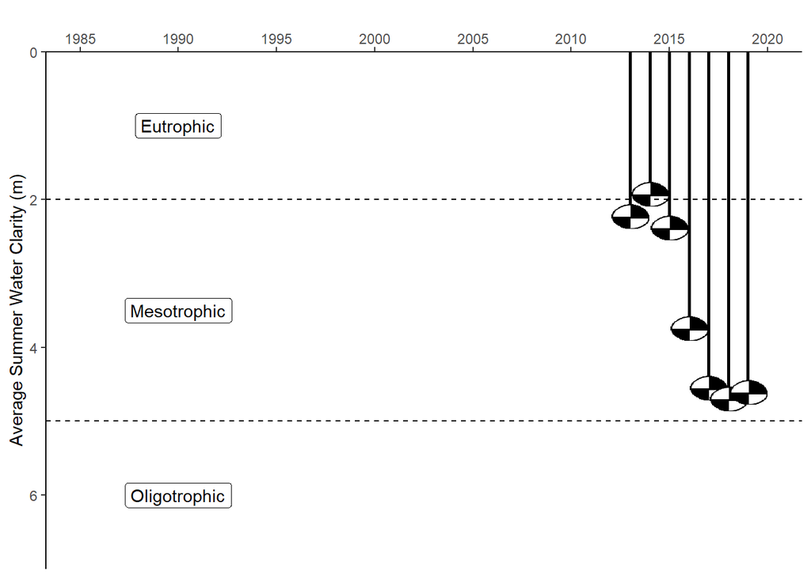

#### Chlorophyll *a*

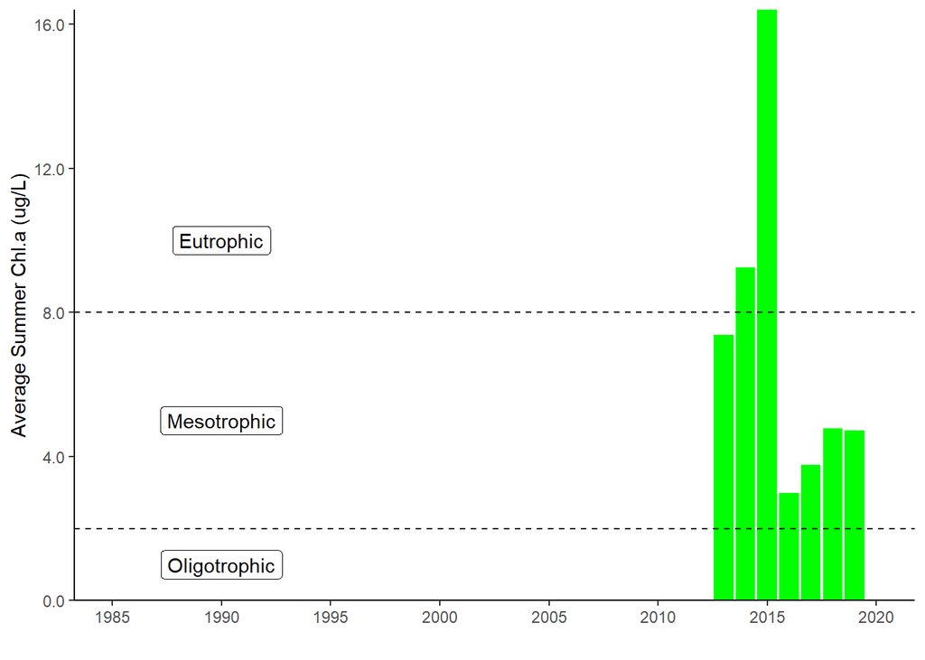

#### Surface and Deep Phosphorus

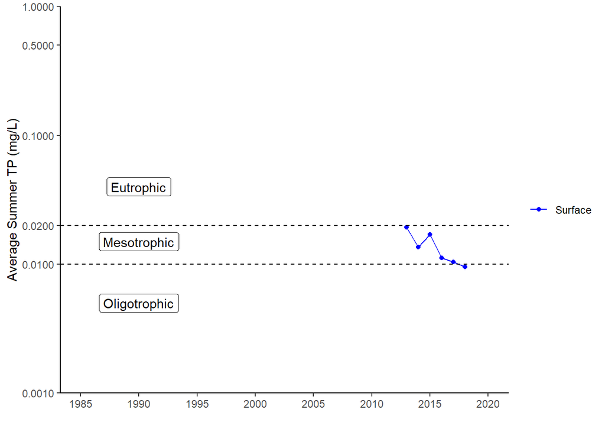

#### Nitrogen

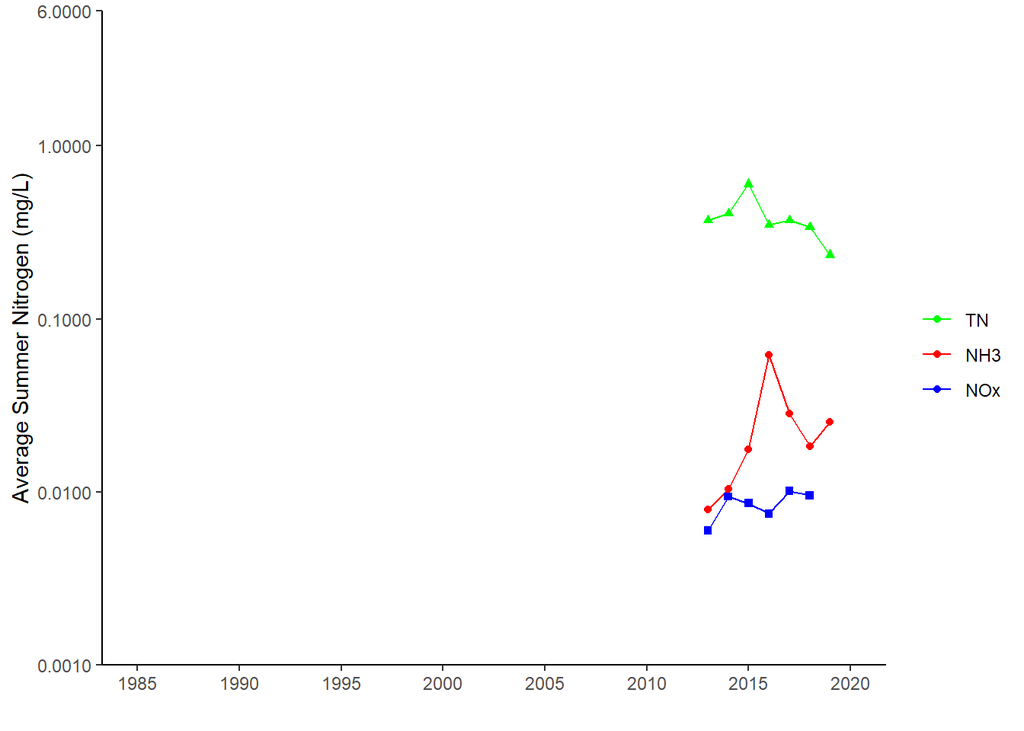

#### TN : TP

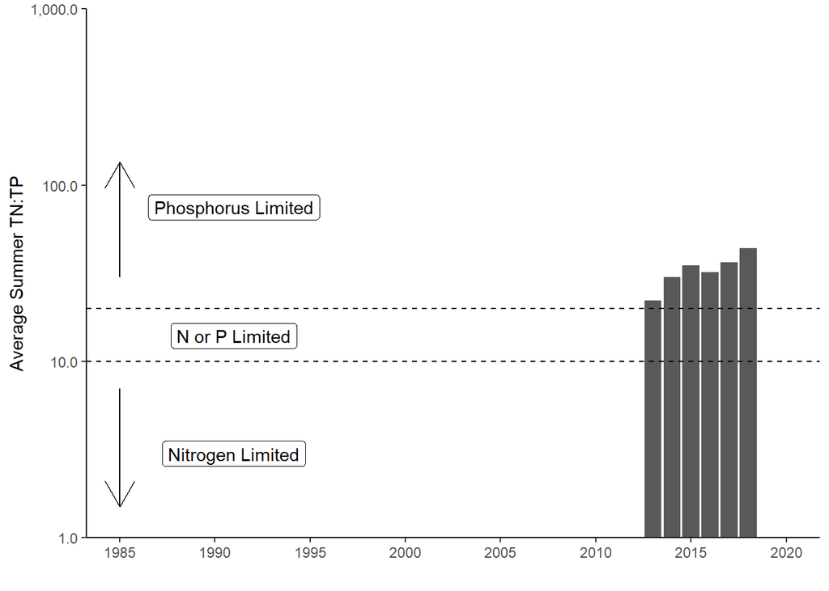

#### pH

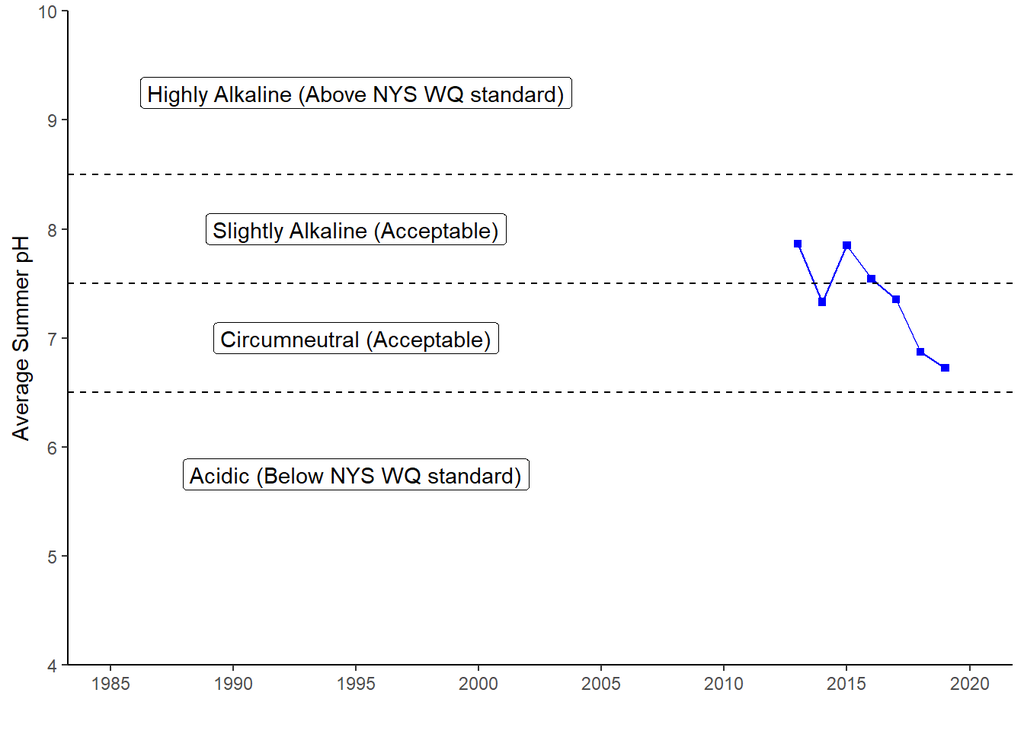

#### Specific Conductance

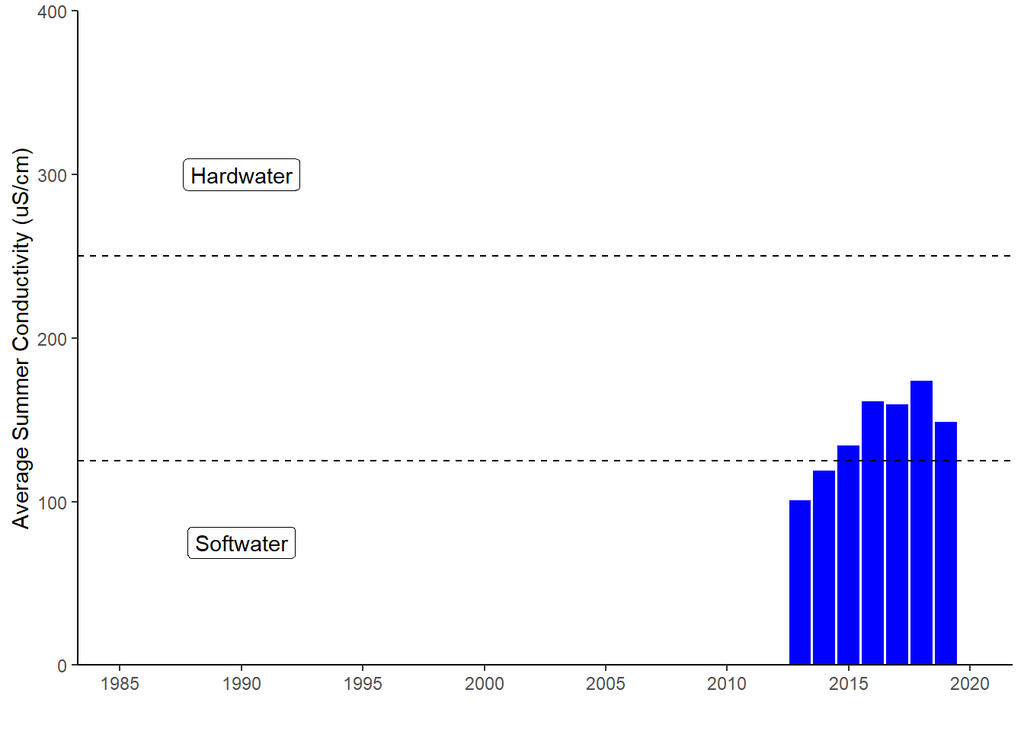

#### Chloride

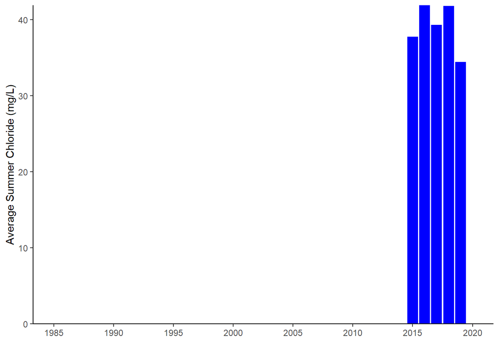

#### Color

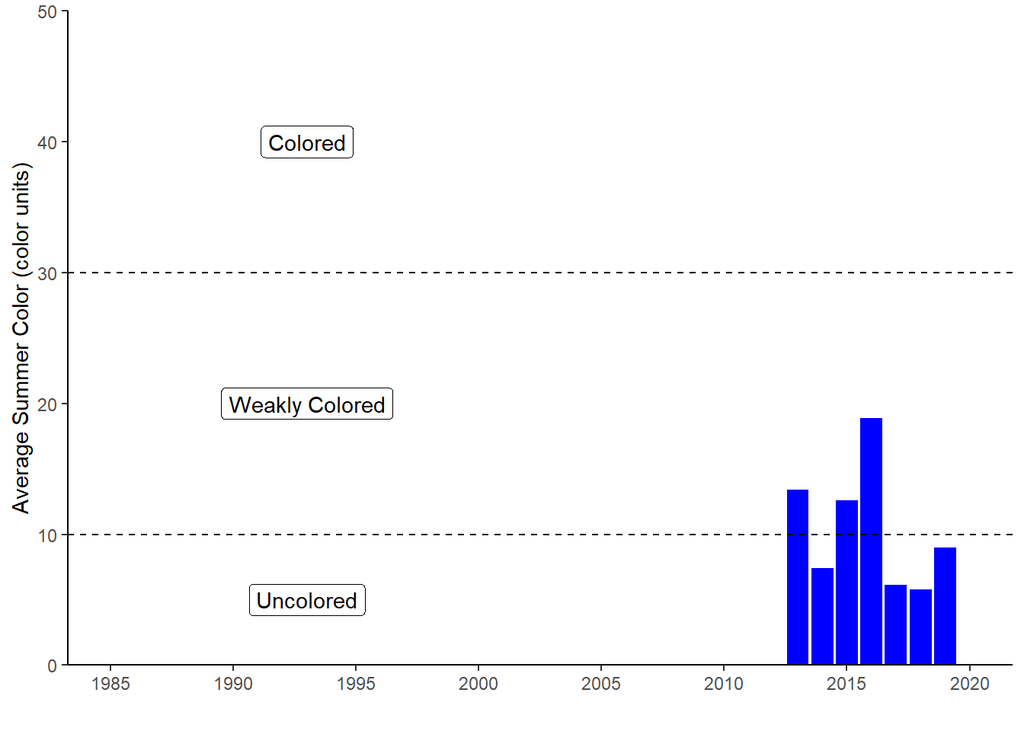

#### Surface and Deep Temperature

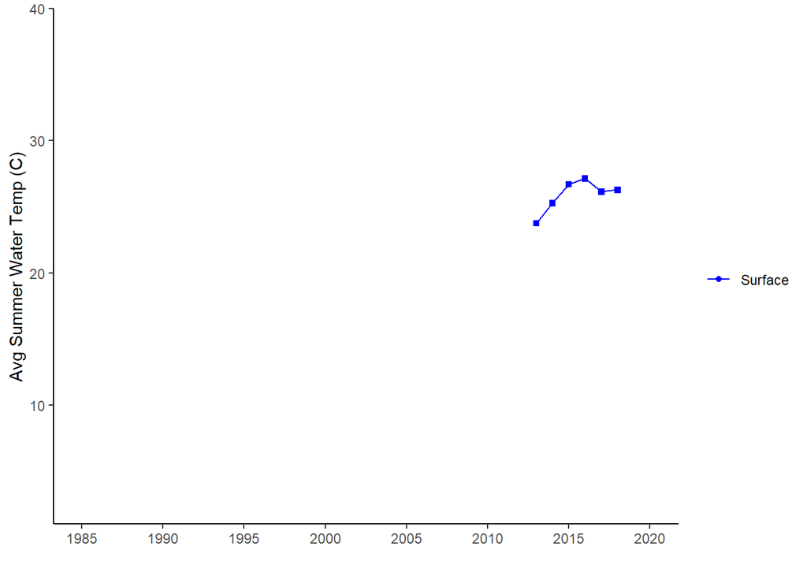

#### Lake Perception

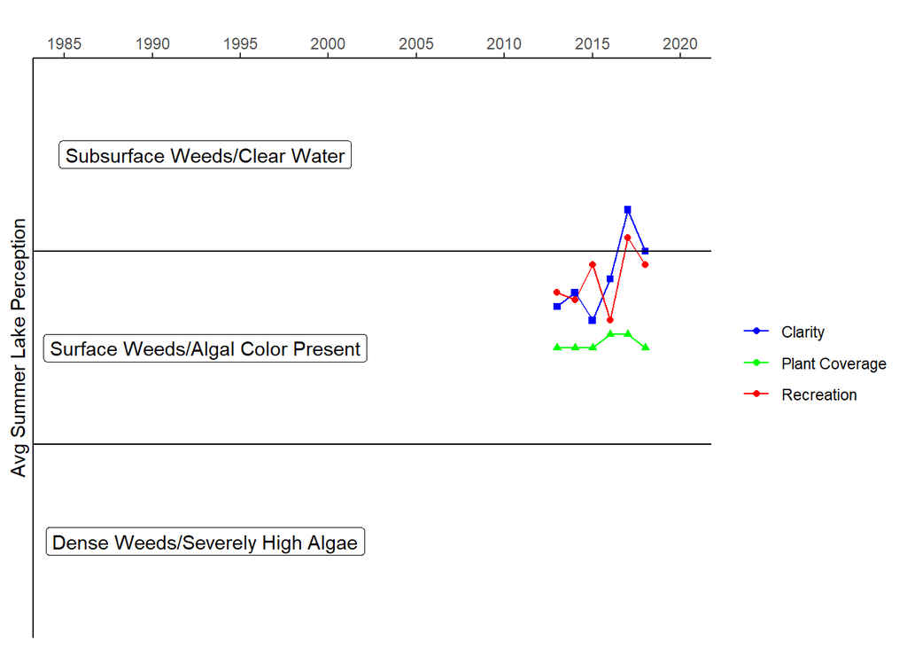

## Montgomery Lake - In-Season Analysis

#### In Season Water Clarity

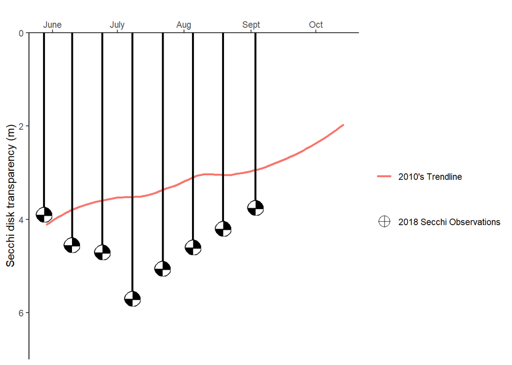

#### In Season Water Temperature

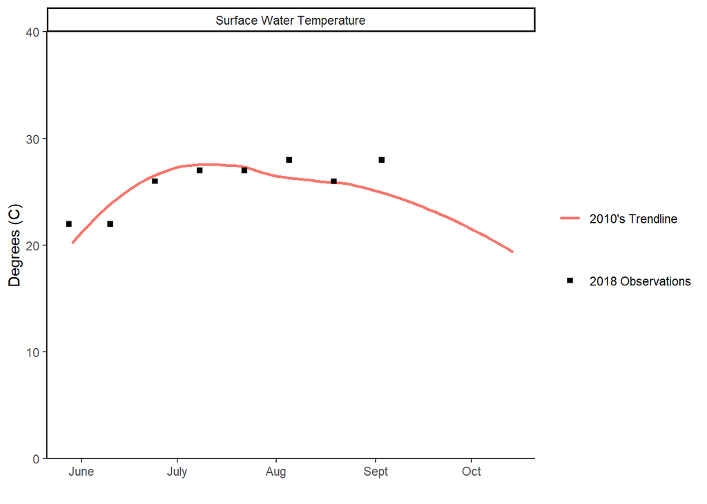